# IBD MS1-only

Loading necessary libraryes

```r
library(renv) #remotes::install_github("rstudio/renv")
#renv::restore()
library(tidyverse)
library(stringr)
library(DESeq2)
library(data.table)
library(dendextend)
library(here)
library(impute)
library(pvclust)
library(gplots)
library(RColorBrewer)
library(cluster)
library(cutr)#devtools::install_github("moodymudskipper/cutr")
library(caret)
library(mlbench)
library(MASS)
library(glmnet)
library(foreach)
library(doParallel)
registerDoParallel(cores=2)
library(stringr)
library(lubridate)
library(umap)
library(sva)
#renv::snapshot()
```

## Data input and normalization

Reading MS1 feature intensity data. We will need to subset to only include the consensus features. We’ll also organize the samples by “Group” (ie Control, CD, UC)

```r
### For the openMS files
## will have to edit...
## sample info ../data/ms1_openms_sampleinfo.csv
ibd_samples <- read.csv(here::here("ibd", "data", "ibd-nc-samples.csv"), header=F)
ibd_samples <- lapply(ibd_samples, trimws)
ms1_openms_metadata <- read.csv(here::here("ibd", "data", "ibd-nc-metadata.csv"))
intensity <- read.csv(here::here("ibd", "data", "ibd-nc_ms1intensity-20mins-100ppm.csv"), row.names=1)
ms_order <- read.csv(here::here("ibd", "data", "ms_order.txt"), sep="\t", header=F)
colnames(ms_order) <- c("Month", "Day", "Year", "File")
ms_order$Date <- paste(ms_order$Month, ms_order$Day, ms_order$Year) %>% mdy(.)
ms_order <- ms_order %>% arrange(., Date)


int_col <- data.frame(Sample.Name = colnames(intensity))
ibd_meta <- right_join(int_col, ms1_openms_metadata, by="Sample.Name") ## only including samples we used
ibd_meta <- ibd_meta %>% mutate(NewName = paste0(Sample.Name, "_", Diagnosis))

ms_order <- ms_order %>% mutate(basename = str_remove(File, ".raw")) %>%
  mutate(basename = str_remove(basename, "/"))
ibd_meta <- ms_order %>% merge(., ibd_samples,  by.y = "V2", by.x="basename", all.y=T) %>% merge(., ibd_meta, by.x="V6", by.y="Sample.Name", all.y=T)
## missing some dates, need to fill in manually
#write.csv(ibd_meta, file=here::here("ibd", "data", "ibd-nc-metadata_dates.csv"))


tryp1 <- intensity %>% filter(between(MZ, 576.0, 577.99)) %>% dplyr::select(feature_num)
#final[complete.cases(final),]
tryp2 <- intensity %>% filter(between(MZ, 1081.0, 1082.99)) %>% dplyr::select(feature_num)

## Want to remove TI site...
#ibd_meta <- ibd_meta %>% dplyr::filter(site != "TI")


## try to reduce number of features...
# reorganize df so that it's in the order of drugs (for filtering)
ibd_meta <- ibd_meta %>% arrange(., Diagnosis)
intensity_info <- intensity %>% dplyr::select(feature_num, RT,MZ)
intensity <- intensity %>% dplyr::select(ibd_meta$V6)
colnames(intensity) <- paste0(colnames(intensity), "_", ibd_meta$Diagnosis)
intensity <- intensity %>% mutate(feat_num = 1:nrow(intensity))



#put_tryp1 <- intensity[tryp1$feature_num,]
#put_tryp1 <- put_tryp1[complete.cases(put_tryp1),]
#rowMeans(put_tryp1 %>% dplyr::select(-feat_num))
#put_tryp2 <- intensity[tryp2$feature_num,]
#put_tryp2 <- put_tryp2[complete.cases(put_tryp2),]

ibd_meta <- ibd_meta %>% mutate(Location = case_when(Intestinal.region == "Ascending colon" ~ "AC",
                                         Intestinal.region == "Terminal ileum" ~ "TI",
                                         Intestinal.region == "Descending colon" ~ "DC"))

## want to do these locations separately
AC_samples <- ibd_meta %>% filter(Location == "AC")
TI_samples <- ibd_meta %>% filter(Location == "TI")
DC_samples <- ibd_meta %>% filter(Location == "DC")

write.csv(AC_samples, here::here("ibd", "ac", "ac-files.csv"), quote=F)
write.csv(TI_samples, here::here("ibd", "ti", "ti-files.csv"), quote=F)
write.csv(DC_samples, here::here("ibd", "dc", "dc-files.csv"), quote=F)
```

I believe there may be too many differences between intestinal regions so we should analyze these datasets separately.

```r
int_AC <- intensity %>% dplyr::select(AC_samples$NewName)
int_TI <- intensity %>% dplyr::select(TI_samples$NewName)
int_DC <- intensity %>% dplyr::select(DC_samples$NewName)

cond_options_all <- table(ibd_meta$Diagnosis) %>% as.data.frame()
cond_opts_all <- cond_options_all$Var1
cond_count_all <- cond_options_all$Freq * 0.5


cond_options_AC <- table(AC_samples$Diagnosis) %>% as.data.frame()
cond_options_TI <- table(TI_samples$Diagnosis) %>% as.data.frame()
cond_options_DC <- table(DC_samples$Diagnosis) %>% as.data.frame()
## options for drug specific filtering
## want to change intensities below a noise threshold for
cond_opts_AC <- cond_options_AC$Var1
cond_count_AC <- cond_options_AC$Freq * 0.5

cond_opts_TI <- cond_options_TI$Var1
cond_count_TI <- cond_options_TI$Freq * 0.5

cond_opts_DC <- cond_options_DC$Var1
cond_count_DC <- cond_options_DC$Freq * 0.5
#intensity[25,]
#intensity[128,]

## Let's normalize intensity to a putative trysin peptide (row 1, or feature_num 1)

#intensity <- intensity %>% filter(feat_num != 1) #%>% dplyr::select(-RT, -MZ)
#
##intensity_norm <- sweep(intensity, 2, put_tryp1, "/")
#put_tryp1 <- as.vector(put_tryp1 %>% dplyr::select(-feat_num))
#
#intensity <- as.matrix(intensity %>% dplyr::select(-feat_num))
#intensity[complete.cases(intensity),] %>% dim()
#
#test <- sweep(intensity, 2, as.matrix(put_tryp1), "/")

## we can reduce the number of features using intensity binning, but I don't believe it is necessary for the IBD data
#int <- intensity %>% as.data.frame %>% pivot_longer(names_to = "Name", values_to="intensity", cols=everything()) %>% drop_na()
#head(int)
#summary(int$intensity)
#int_4_quartiles <- smart_cut(int$intensity,4,"groups", labels = c("remove", "Low", "Med", "High"))
#table(int_4_quartiles)
#int$quart <- int_4_quartiles
#max_to_remove <- int %>% filter(quart == "remove")
#max_to_remove <- max_to_remove$intensity %>% max()
#
#dens <- density(log2(int$intensity))
#df <- data.frame(x=dens$x, y=dens$y)
#probs <- c(0,0.25,0.5,0.75,1)
#quantiles <- quantile(log2(int$intensity), prob=probs)
#df$quant <- factor(findInterval(df$x,quantiles))
#
#
#(pep_quart_plot <- ggplot(df, aes(x,y)) + geom_line() +
#    geom_ribbon(aes(ymin=0, ymax=y, fill=quant)) +
#    scale_x_continuous(breaks=quantiles) +
#    #scale_fill_brewer(guide="none") +
#    xlab("MS1 feature intensities") +
#    ylab("Density") +
#    scale_fill_viridis_d(option = "plasma", guide = "none") +
#    theme_bw() +
#    theme(text=element_text(size=14))
#)
#
#
#ms_order %>% head(n=10)
#
### Match run order to meta data
#
#
#
###
#earlyruns <- intensity %>% dplyr::select(., matches("HM621PCA|HM621TIA|HM621TIN|HM504TIN|HM565TIN|HM421TI|HM421CO|HM565TIA|HM504PCA|HM565PCN")) #, HM621TIN, HM504TIN, HM565TIN, HM421TI
#
#int <- earlyruns %>% pivot_longer(names_to = "Name", values_to="intensity", cols=everything()) %>% drop_na()
#head(int)
#summary(int$intensity)
#int_4_quartiles <- smart_cut(int$intensity,4,"groups", labels = c("remove", "Low", "Med", "High"))
#table(int_4_quartiles)
#int$quart <- int_4_quartiles
#max_to_remove <- int %>% filter(quart == "remove")
#max_to_remove <- max_to_remove$intensity %>% max()
#
#dens <- density(log2(int$intensity))
#df <- data.frame(x=dens$x, y=dens$y)
#probs <- c(0,0.25,0.5,0.75,1)
#quantiles <- quantile(log2(int$intensity), prob=probs)
#df$quant <- factor(findInterval(df$x,quantiles))
#
#
#(pep_quart_plot <- ggplot(df, aes(x,y)) + geom_line() +
#    geom_ribbon(aes(ymin=0, ymax=y, fill=quant)) +
#    scale_x_continuous(breaks=quantiles) +
#    #scale_fill_brewer(guide="none") +
#    xlab("MS1 feature intensities") +
#    ylab("Density") +
#    scale_fill_viridis_d(option = "plasma", guide = "none") +
#    theme_bw() +
#    theme(text=element_text(size=14))
#)
#
### can see that there is an issue with batches.
### we can normalize using highly abundant features across all samples
#full_quant <- rowSums(is.na(intensity))
#
#
#ggsave(here::here("figs", "ms1quart.pdf"), pep_quart_plot, width = 10, height = 6, units = "in")
### separating by Control, UC and CD
#int_CD <- int %>% filter(stringr::str_detect(Name, "CD"))
#
#int_4_quartiles <- smart_cut(int_CD$intensity,4,"groups", labels = c("remove", "Low", "Med", "High"))
#table(int_4_quartiles)
#int_CD$quart <- int_4_quartiles
#max_to_remove <- int_CD %>% filter(quart == "remove")
#max_to_remove <- max_to_remove$intensity %>% max()
#
#dens <- density(log2(int_CD$intensity))
#df <- data.frame(x=dens$x, y=dens$y)
#probs <- c(0,0.25,0.5,0.75,1)
#quantiles <- quantile(log2(int$intensity), prob=probs)
#df$quant <- factor(findInterval(df$x,quantiles))
#
#
#(pep_quart_plot <- ggplot(df, aes(x,y)) + geom_line() +
#    geom_ribbon(aes(ymin=0, ymax=y, fill=quant)) +
#    scale_x_continuous(breaks=quantiles) +
#    #scale_fill_brewer(guide="none") +
#    xlab("MS1 feature intensities") +
#    ylab("Density") +
#    scale_fill_viridis_d(option = "plasma", guide = "none") +
#    theme_bw() +
#    theme(text=element_text(size=14))
#)
#
##ggsave(here::here("figs", "ms1quart.pdf"), pep_quart_plot, width = 10, height = 6, units = "in")

is.nan.data.frame <- function(x){
    do.call(cbind, lapply(x, is.nan))}
#df = intensity
#conditions = cond_opts
#min_count = cond_count
## add condition to end of all col names...
filter_valids_quart = function(df, conditions, min_count, int_remove, at_least_one = TRUE) {
    df[is.nan.data.frame(df)] <- 0
    df[is.na(df)] <- 0
    df[df <= int_remove] <- 0
    all_names <- colnames(df)
    cond.names = lapply(conditions, # Group column names by conditions
                        function(x) grep(x, all_names, value = TRUE, perl = TRUE))
    cond.filter = sapply(1:length(cond.names), function(i) {
        df2 = df %>% dplyr::select(cond.names[[i]])   # Extract columns of interest
        df2 = as.matrix(df2)   # Cast as matrix for the following command
        sums = rowSums(df2!=0) # count the number of valid values for each condition
        sums >= min_count[i]   # Calculates whether min_count requirement is met
    })
    if (at_least_one) {
        df$KEEP = apply(cond.filter, 1, any)
    } else {
        df$KEEP = apply(cond.filter, 1, all)
    }
    return(df)  # only keeping rows that meet the criteria!
}



## filter by at least Q50 in each treatment considering ZEROS and anything in low quartile
## trying without any quartile adjustment!
ibd_filt_all <- filter_valids_quart(intensity[,-177],
                               conditions = cond_opts_all,
                               min_count = cond_count_all,
                               int_remove = 1,
                               at_least_one = T) #235,216
ibd_filt_all <- intensity[ibd_filt_all$KEEP == 1,-177] ## 20,820
all_filt_feat <- rownames(ibd_filt_all)


ibd_filt_DC <- filter_valids_quart(int_DC,
                               conditions = cond_opts_DC,
                               min_count = cond_count_DC,
                               int_remove = 1,
                               at_least_one = T) #235,216
ibd_filt_DC <- int_DC[ibd_filt_DC$KEEP == 1,] ## 25,952
DC_filt_feat <- rownames(ibd_filt_DC)



ibd_filt_AC <- filter_valids_quart(int_AC,
                               conditions = cond_opts_AC,
                               min_count = cond_count_AC,
                               int_remove = 1,
                               at_least_one = T) #235,216
ibd_filt_AC <- int_AC[ibd_filt_AC$KEEP == 1,] ## 23,804
AC_filt_feat <- rownames(ibd_filt_AC)

ibd_filt_TI <- filter_valids_quart(int_TI,
                               conditions = cond_opts_TI,
                               min_count = cond_count_TI,
                               int_remove = 1,
                               at_least_one = T) #235,216
ibd_filt_TI <- int_TI[ibd_filt_TI$KEEP == 1,] ## 23,716
TI_filt_feat <- rownames(ibd_filt_TI)



## can further explore features if needed!!

#is.nan(intensity) <- 0
norm_feat_all <- estimateSizeFactorsForMatrix(ibd_filt_all)
norm_int_all <- sweep(ibd_filt_all, 2, norm_feat_all, "/") ##peptides are normalized

norm_feat_TI <- estimateSizeFactorsForMatrix(ibd_filt_TI)
norm_int_TI <- sweep(ibd_filt_TI, 2, norm_feat_TI, "/") ##peptides are normalized

norm_feat_AC <- estimateSizeFactorsForMatrix(ibd_filt_AC)
norm_int_AC <- sweep(ibd_filt_AC, 2, norm_feat_AC, "/") ##peptides are normalized

norm_feat_DC <- estimateSizeFactorsForMatrix(ibd_filt_DC)
norm_int_DC <- sweep(ibd_filt_DC, 2, norm_feat_DC, "/") ##peptides are normalized
```

## Missing data imputation

Although we filtered data, we are still left with missing values that will cause challenges with log transformation and fold change calculations. We used a KNN data imputation.

```r
## impute missing values
#intensity_0 <- intensity %>%  mutate_all(~replace(., is.nan(.), 0))

imputed_pep_all<- impute.knn(norm_int_all %>% as.matrix(), k = 10, rowmax = 0.5, colmax = 0.95, rng.seed = 362436069)
```

[output not shown]

[output cut: 53 more lines]

[output not shown]

```r
#imputed_pep_DC<- impute.knn(norm_int_DC %>% as.matrix(), k = 10, rowmax = 0.5, colmax = 0.95, rng.seed = 362436069)

#imputed_pep_AC<- impute.knn(norm_int_AC %>% as.matrix(), k = 10, rowmax = 0.5, colmax = 0.95, rng.seed = 362436069)

#imputed_pep_TI<- impute.knn(norm_int_TI %>% as.matrix(), k = 10, rowmax = 0.5, colmax = 0.95, rng.seed = 362436069)
```

## Batch effect?

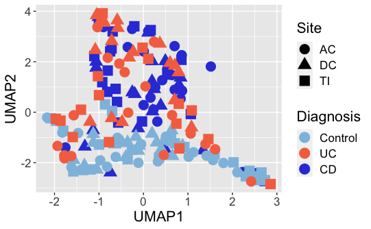

```r
ms1_umap_all <- umap(imputed_pep_all$data %>% as.matrix %>% t(), n_components=2, random_state=2248)
#ibd_meta <- ibd_meta[match(colnames(log_exp), ibd_meta$NewName),]
coords_umap_all<-data.frame(ms1_umap_all$layout, Diagnosis = ibd_meta$Diagnosis,
                   #samplename = colnames(log_exp_DC),
                   Sex = ibd_meta$Gender,
                   Site = ibd_meta$Location,
                   Inflammed = ibd_meta$Inflammed, Date=ibd_meta$Date)
coords_umap_all$Diagnosis <- factor(coords_umap_all$Diagnosis, levels = c("Control", "UC", "CD"))
coords_umap_all$Inflammed <- factor(coords_umap_all$Inflammed, levels = c("Yes","No"))
labels <- pretty(coords_umap_all$Date, 5)
(umap_plot_all_diag <- ggplot(coords_umap_all, aes(x = X1, y = X2)) +
        geom_point(size=5, aes(shape = Site, color = Diagnosis)) +
        scale_color_manual(values=c("#8FBFE0", "#F57251",  "#3444DA")) +
        #scale_color_gradient(
  #  low="yellow", high="purple",
  #  breaks = as.integer(labels),
  #  labels = format(labels, "%m/%d/%y")
 # ) +
        scale_x_continuous(name="UMAP1") +
        scale_y_continuous(name="UMAP2") +
        #theme_bw() +
        theme(legend.position = "right", text=element_text(size=16)))
```

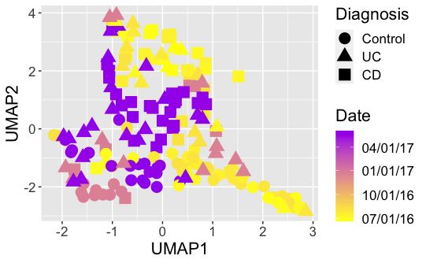

```r
(umap_plot_all <- ggplot(coords_umap_all, aes(x = X1, y = X2)) +
        geom_point(size=5, aes(shape = Diagnosis, color = Date)) +
        #scale_color_manual(values=c("#3444DA",  "#DF737A", "#8C5999", "#00916E", "#D7C0D0", "#FFBA49")) +
        scale_color_gradient(
    low="yellow", high="purple",
    breaks = as.integer(labels),
    labels = format(labels, "%m/%d/%y")
  ) +
        scale_x_continuous(name="UMAP1") +
        scale_y_continuous(name="UMAP2") +
        #theme_bw() +
        theme(legend.position = "right", text=element_text(size=16)))
```

```r
#ggsave(filename = "../figs/umap-ibd-diagnosis.pdf", umap_plot_all_diag, width = 8, height = 6, units = "in")
#ggsave(filename = "../figs/umap-ibd-date.pdf", umap_plot_all, width = 8, height = 6, units = "in")
```

## Log2 intensity transformation and PCA quality check

We then should log transform the intensity values and perform a PCA for a QC check.

```r
## easy and quick PCA funcDCon for manual colour and shape
quick_pca_date <- function(coords_df, x_PC, y_PC, PoV, shape, fill){
    yaxis <- y_PC
    xaxis <- x_PC
    yperc <- paste0("(", round(PoV[yaxis %>% as.numeric()] ,2), "%)")
    xperc <- paste0("(", round(PoV[xaxis %>% as.numeric()] ,2), "%)")
    yaxislabel <- paste0("PC", yaxis, " ", yperc)
    xaxislabel <- paste0("PC", xaxis, " ", xperc)
    pca_plot <- ggplot(coords_df, aes_string(x = paste0('PC', xaxis), y = paste0('PC', yaxis))) +
        geom_point(size=4, aes_string(shape = shape, color = fill)) +
        #scale_color_manual(values=c("#3444DA",  "#DF737A", "#8C5999", "#00916E", "#D7C0D0", "#FFBA49")) +
  scale_color_gradient(
    low="yellow", high="purple",
    breaks = as.integer(labels),
    labels = format(labels, "%m/%d/%y")
  ) +
      scale_x_continuous(name=xaxislabel) +
        scale_y_continuous(name=yaxislabel) +
        theme_bw() +
        theme(legend.position = "right", text=element_text(size=16))
    return(pca_plot)
}


log_exp_all <- data.frame(imputed_pep_all$data) %>%
    mutate_all(., funs(log2(1 + .)))
colnames(log_exp_all) = colnames(imputed_pep_all$data)
pca_all<- prcomp(log_exp_all %>% t(), center=T, scale=F)
sampleVals_all<-data.frame(pca_all$x)
exprVals_all<-data.frame(pca_all$rotation)
PoV_all <- (pca_all$sdev^2/sum(pca_all$sdev^2))*100

coords_all<-data.frame(sampleVals_all, Group = ibd_meta$Diagnosis,
                   samplename = rownames(sampleVals_all),
                   Sex = ibd_meta$Gender,
                   Site = ibd_meta$Location,
                   Inflammed = ibd_meta$Inflammed, Date=ibd_meta$Date) #,
                   #Age = ibd_meta$Age)
coords_all$Group <- factor(coords_all$Group, levels = c("Control", "UC", "CD"))
numPCs_all <- 1:length(PoV_all)

for (i in 1:length(PoV_all)) {
    percent <- paste0("(", round(PoV_all[i],2), "%)")
    name <- paste0("PC", i, "per")
    assign(name, percent)
}
(pc12_all <- quick_pca(coords_df = coords_all, x_PC = 2, y_PC = 1, PoV = PoV_DC, shape = "Site", fill = "Group"))
```

[output not shown]

### Descending colon region

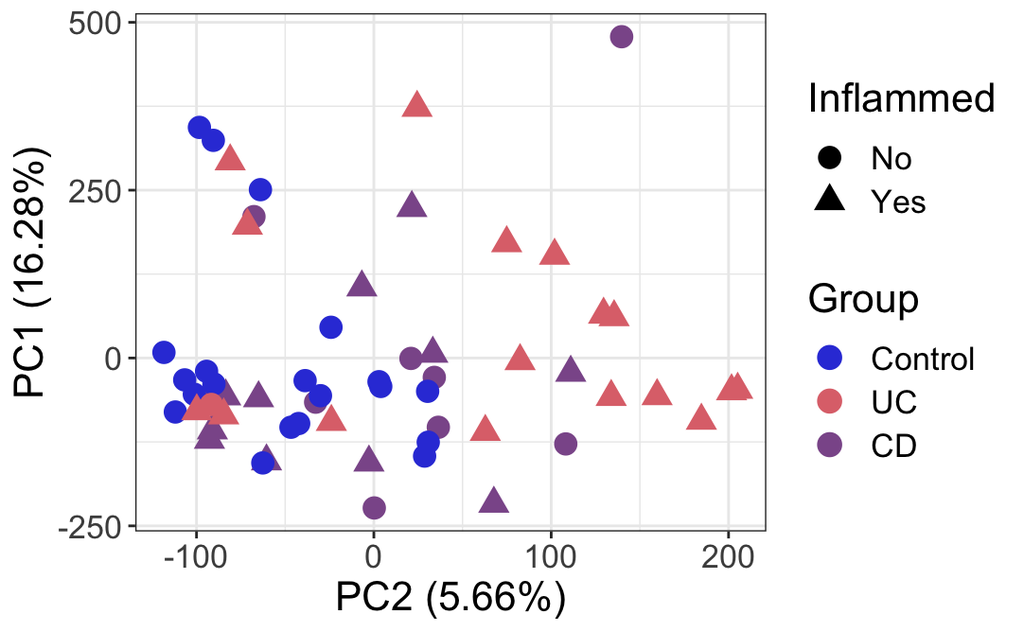

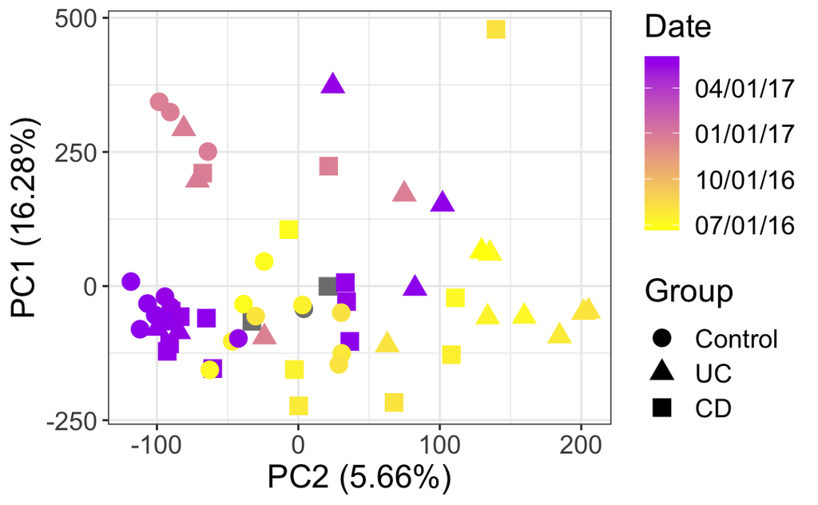

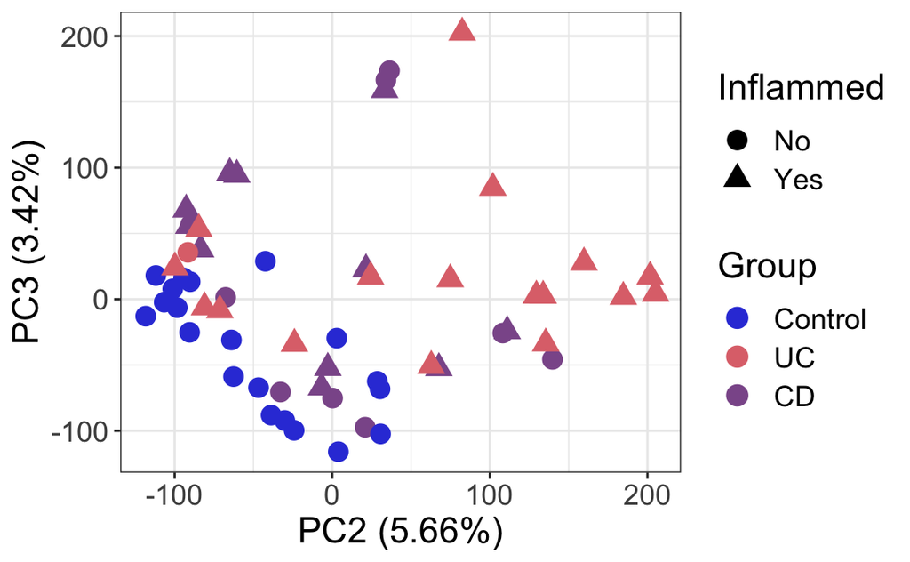

```r
(pc12_DC <- quick_pca(coords_df = coords_DC, x_PC = 2, y_PC = 1, PoV = PoV_DC, shape = "Inflammed", fill = "Group"))
(pc12_DC <- quick_pca_date(coords_df = coords_DC, x_PC = 2, y_PC = 1, PoV = PoV_DC, shape = "Group", fill = "Date"))



(pc23_DC <- quick_pca(coords_df = coords_DC, x_PC = 2, y_PC = 3, PoV = PoV_DC, shape = "Inflammed", fill = "Group"))
```

### Ascending colon region

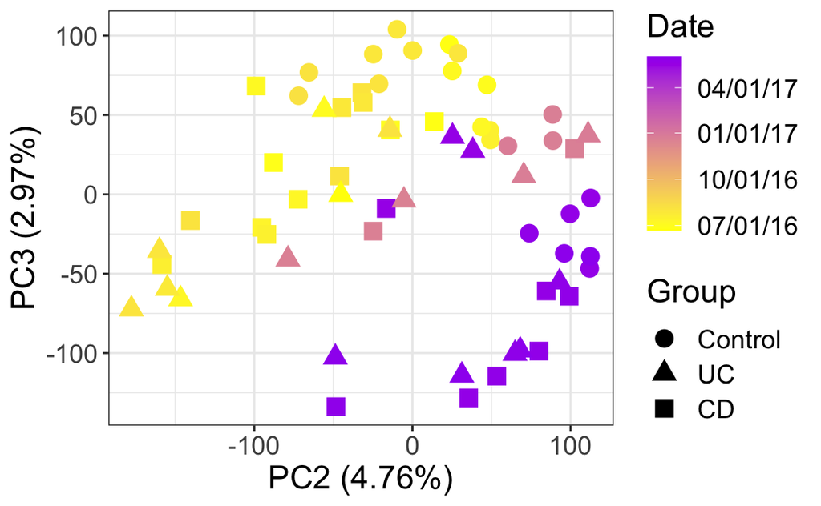

### Terminal illium region

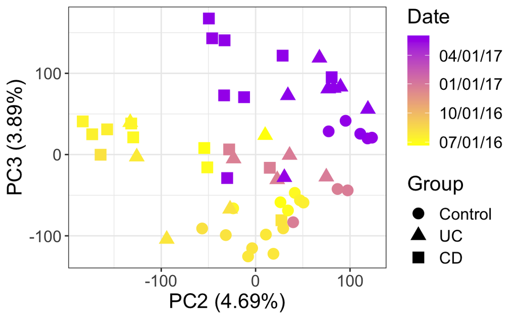

## UMAP

You refer to these as “projections”

### Descending colon

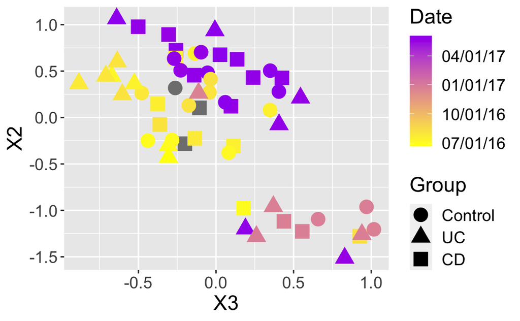

```r
#colnames(log_exp) = colnames(imputed_pep$data)

ms1_umap_DC <- umap(log_exp_DC %>% t(), n_components=4, random_state=2248)
#ibd_meta <- ibd_meta[match(colnames(log_exp), ibd_meta$NewName),]
coords_umap_DC<-data.frame(ms1_umap_DC$layout, Group = DC_samples$Diagnosis,
                   samplename = colnames(log_exp_DC),
                   Sex = DC_samples$Gender,
                   #Site = DC_sample$Intestinal.region,
                   Inflammed = DC_samples$Inflammed, Date=DC_samples$Date)
coords_umap_DC$Group <- factor(coords_umap_DC$Group, levels = c("Control", "UC", "CD"))
labels <- pretty(coords_umap_DC$Date, 5)
(umap_plot_DC <- ggplot(coords_umap_DC, aes(x = X3, y = X2)) +
        geom_point(size=5, aes(shape = Group, color = Date)) +
        #scale_color_manual(values=c("#3444DA",  "#DF737A", "#8C5999", "#00916E", "#D7C0D0", "#FFBA49")) +
        scale_color_gradient(
    low="yellow", high="purple",
    breaks = as.integer(labels),
    labels = format(labels, "%m/%d/%y")
  ) +
       # scale_x_continuous(name="UMAP1") +
      #  scale_y_continuous(name="UMAP2") +
        #theme_bw() +
        theme(legend.position = "right", text=element_text(size=16)))
```

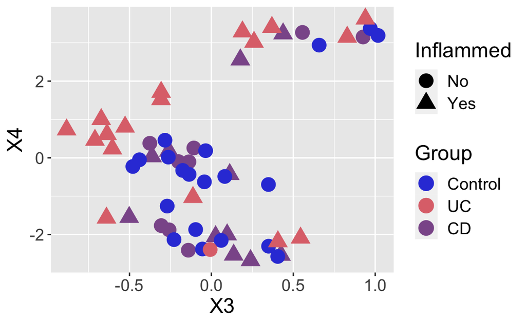

```r
(umap_plot_DC <- ggplot(coords_umap_DC, aes(x = X3, y = X4)) +
        geom_point(size=5, aes(shape = Inflammed, color = Group)) +
        scale_color_manual(values=c("#3444DA",  "#DF737A", "#8C5999", "#00916E", "#D7C0D0", "#FFBA49")) +
       # scale_color_gradient(
    #low="yellow", high="purple",
    #breaks = as.integer(labels),
    #labels = format(labels, "%m/%d/%y")
  #) +
       # scale_x_continuous(name="UMAP1") +
      #  scale_y_continuous(name="UMAP2") +
        #theme_bw() +
        theme(legend.position = "right", text=element_text(size=16)))
```

```r
#umap_plot
#new_clust <- coords_umap %>% filter(X1 < 0 & X2 > 0)

#write.csv(new_clust, file=here::here("ibd", "data", "recentmsruns_cluster.csv"))
```

### Ascending colon

```r
#colnames(log_exp) = colnames(imputed_pep$data)

ms1_umap_AC <- umap(log_exp_AC %>% t(), n_components=4, random_state=2248)
#ibd_meta <- ibd_meta[match(colnames(log_exp), ibd_meta$NewName),]
coords_umap_AC<-data.frame(ms1_umap_AC$layout, Group = AC_samples$Diagnosis,
                   samplename = colnames(log_exp_AC),
                   Sex = AC_samples$Gender,
                   #Site = AC_sample$Intestinal.region,
                   Inflammed = AC_samples$Inflammed, Date=AC_samples$Date)
coords_umap_AC$Group <- factor(coords_umap_AC$Group, levels = c("Control", "UC", "CD"))
labels <- pretty(coords_umap_AC$Date, 5)
(umap_plot_AC <- ggplot(coords_umap_AC, aes(x = X1, y = X2)) +
        geom_point(size=5, aes(shape = Group, color = Date)) +
       # scale_color_manual(values=c("#3444DA",  "#DF737A", "#8C5999", "#00916E", "#D7C0D0", "#FFBA49")) +
        scale_color_gradient(
          low="yellow", high="purple",
          breaks = as.integer(labels),
          labels = format(labels, "%m/%d/%y")
      ) +
       # scale_x_continuous(name="UMAP1") +
      #  scale_y_continuous(name="UMAP2") +
        #theme_bw() +
        theme(legend.position = "right", text=element_text(size=16)))

(umap_plot_AC <- ggplot(coords_umap_AC, aes(x = X3, y = X2)) +
        geom_point(size=5, aes(shape = Group, color = Date)) +
        #scale_color_manual(values=c("#3444DA",  "#DF737A", "#8C5999", "#00916E", "#D7C0D0", "#FFBA49")) +
        scale_color_gradient(
    low="yellow", high="purple",
    breaks = as.integer(labels),
    labels = format(labels, "%m/%d/%y")
  ) +
       # scale_x_continuous(name="UMAP1") +
      #  scale_y_continuous(name="UMAP2") +
        #theme_bw() +
        theme(legend.position = "right", text=element_text(size=16)))


#umap_plot
#new_clust <- coords_umap %>% filter(X1 < 0 & X2 > 0)

#write.csv(new_clust, file=here::here("ibd", "data", "recentmsruns_cluster.csv"))
```

### Terminal illium

```r
#colnames(log_exp) = colnames(imputed_pep$data)

ms1_umap_TI <- umap(log_exp_TI %>% t(), n_components=4, random_state=2248)
#ibd_meta <- ibd_meta[match(colnames(log_exp), ibd_meta$NewName),]
coords_umap_TI<-data.frame(ms1_umap_TI$layout, Group = TI_samples$Diagnosis,
                   samplename = colnames(log_exp_TI),
                   Sex = TI_samples$Gender,
                   #Site = TI_sample$Intestinal.region,
                   Inflammed = TI_samples$Inflammed, Date=TI_samples$Date)
coords_umap_TI$Group <- factor(coords_umap_TI$Group, levels = c("Control", "UC", "CD"))
labels <- pretty(coords_umap_TI$Date, 5)
(umap_plot_TI <- ggplot(coords_umap_TI, aes(x = X1, y = X2)) +
        geom_point(size=5, aes(shape = Group, color = Date)) +
       # scale_color_manual(values=c("#3444DA",  "#DF737A", "#8C5999", "#00916E", "#D7C0D0", "#FFBA49")) +
        scale_color_gradient(
          low="yellow", high="purple",
          breaks = as.integer(labels),
          labels = format(labels, "%m/%d/%y")
      ) +
       # scale_x_continuous(name="UMAP1") +
      #  scale_y_continuous(name="UMAP2") +
        #theme_bw() +
        theme(legend.position = "right", text=element_text(size=16)))

(umap_plot_TI <- ggplot(coords_umap_TI, aes(x = X3, y = X2)) +
        geom_point(size=5, aes(shape = Group, color = Date)) +
        #scale_color_manual(values=c("#3444DA",  "#DF737A", "#8C5999", "#00916E", "#D7C0D0", "#FFBA49")) +
        scale_color_gradient(
    low="yellow", high="purple",
    breaks = as.integer(labels),
    labels = format(labels, "%m/%d/%y")
  ) +
       # scale_x_continuous(name="UMAP1") +
      #  scale_y_continuous(name="UMAP2") +
        #theme_bw() +
        theme(legend.position = "right", text=element_text(size=16)))


#umap_plot
#new_clust <- coords_umap %>% filter(X1 < 0 & X2 > 0)

#write.csv(new_clust, file=here::here("ibd", "data", "recentmsruns_cluster.csv"))
```

## Calculating log2 fold change

We are using [precise-db’s](https://github.com/SBRG/precise-db) implementation of robust components in ICA matrix decomposition. This implementation required fold change values.

We need to write this log2 FC to a file because the ICA implementation is written in Python.

### All samples

```r
ctrl_all <- dplyr::select(log_exp_all, contains("Control"))
ctrl_all$median = apply(ctrl_all, 1, median, na.rm = T)
group_temp_all <- dplyr::select(log_exp_all, -contains("Control"))
ctrl_all<- matrix(ctrl_all$median, nrow=length(ctrl_all$median), ncol=ncol(group_temp_all), byrow=F)

fc_all <- ctrl_all - group_temp_all

all_samples_noctrl <- ibd_meta  %>% dplyr::filter(Diagnosis != "Control")# %>%
    #mutate(Name = paste0(., "_", Groups))

fc_all <- fc_all %>% dplyr::select(all_samples_noctrl$NewName)
#write.csv(fc_all, here::here("ibd","data", "nc-ibd_ms1_fc-all.csv"), quote=F, row.names = T)
```

### Descending colon

```r
ctrl_DC <- dplyr::select(log_exp_DC, contains("Control"))
ctrl_DC$median = apply(ctrl_DC, 1, median, na.rm = T)
group_temp_DC <- dplyr::select(log_exp_DC, -contains("Control"))
ctrl_DC<- matrix(ctrl_DC$median, nrow=length(ctrl_DC$median), ncol=ncol(group_temp_DC), byrow=F)

fc_DC <- ctrl_DC - group_temp_DC

DC_samples_noctrl <- DC_samples  %>% dplyr::filter(Diagnosis != "Control")# %>%
    #mutate(Name = paste0(., "_", Groups))

fc_DC <- fc_DC %>% dplyr::select(DC_samples_noctrl$NewName)
#write.csv(fc_DC, here::here("ibd","data", "nc-ibd_ms1_fc-DC.csv"), quote=F, row.names = T)
```

### Ascending colon

```r
ctrl_AC <- dplyr::select(log_exp_AC, contains("Control"))
ctrl_AC$median = apply(ctrl_AC, 1, median, na.rm = T)
group_temp_AC <- dplyr::select(log_exp_AC, -contains("Control"))
ctrl_AC<- matrix(ctrl_AC$median, nrow=length(ctrl_AC$median), ncol=ncol(group_temp_AC), byrow=F)

fc_AC <- ctrl_AC - group_temp_AC

AC_samples_noctrl <- AC_samples  %>% dplyr::filter(Diagnosis != "Control")# %>%
    #mutate(Name = paste0(., "_", Groups))

fc_AC <- fc_AC %>% dplyr::select(AC_samples_noctrl$NewName)
#write.csv(fc_AC, here::here("ibd","data", "nc-ibd_ms1_fc-AC.csv"), quote=F, row.names = T)
```

### Terminal Illium

```r
ctrl_TI <- dplyr::select(log_exp_TI, contains("Control"))
ctrl_TI$median = apply(ctrl_TI, 1, median, na.rm = T)
group_temp_TI <- dplyr::select(log_exp_TI, -contains("Control"))
ctrl_TI<- matrix(ctrl_TI$median, nrow=length(ctrl_TI$median), ncol=ncol(group_temp_TI), byrow=F)

fc_TI <- ctrl_TI - group_temp_TI

TI_samples_noctrl <- TI_samples  %>% dplyr::filter(Diagnosis != "Control")# %>%
    #mutate(Name = paste0(., "_", Groups))

fc_TI <- fc_TI %>% dplyr::select(TI_samples_noctrl$NewName)
#write.csv(fc_TI, here::here("ibd","data", "nc-ibd_ms1_fc-TI.csv"), quote=F, row.names = T)
```

## Clustering

Clustering can be completed the following scripts provided in `bin/`. The ICA implementation of precise-db requires a conda environment which can be accessed using `conda activate precise-db`.

Once ICA has completed it’s run, you will find `S.csv` (and other relevent files) in your chosen output directory. We will be clustering this matrix using `kmed_clustering.py` This script was written considering the newest versions of used packages, thus, `kmed_clustering.py` also has it’s own `conda` environment named `k-med`.

The following should be run in your terminal and requires `conda` and `python`.

```r
## THIS IS A SHELL SCRIPT
## It is best to run this in it's own terminal window because of RStudio's memory limitations
## biolinux ~/software/MetaProClust-MS1
cd ./bin
# You will need to create a specifsc conda environment for ICA.
# Uncomment the code below to create the environment
# conda env create -f environment.yml
conda activate precise-db
## script for robust ICA matrix decomposition
## Update -n to as many threads you have available; ideally at least 6
## However this will run on a laptop with fewer cores, it just may take longer
sh ./precise-db run_ica.sh -i 100 -t 1e-8 -n 6 -o ../../data/msms/ -l ../../data/msms/ica.log ../../data/msms/ms2_fc.csv
conda deactivate

# to create the correct conda environment for clustering
#conda env create -f k-med_env.yml
# This k-medoid clustering relies on newer modules than the ica implementation
conda activate k-med
./kmed_clutering.py -s ../data/msms/S.csv -n 10 -d ../data/msms/ ## reduce n (number of threads to your needs)
conda deactivate
```

## Choosing number of clusters

Max silhouette scores are failing on this dataset.

Instead, let’s use the inertia scores to choose a k value using the elbow method to see where inertia begins to slow!

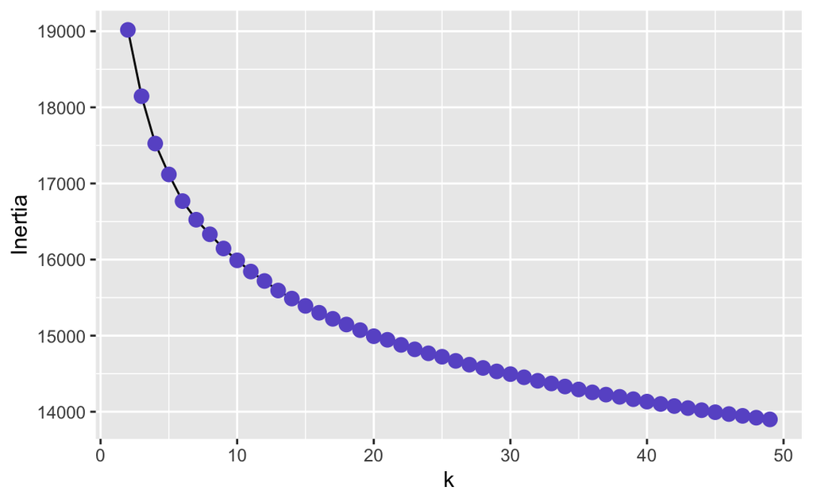

```r
inertia_all <- read.csv(here::here("ibd", "all", "k-med_inertia_all.csv"), header=F) %>% data.frame(inertia = ., k = 2:49)

silhouette_all <- read.csv(here::here("ibd", "all", "k-med_sil_all.csv"), header=F) %>% data.frame(inertia = ., k = 2:49)

ggplot(inertia_all,aes(x=k, y=V1)) +
  geom_line() +
  geom_point(size=3, colour="slateblue") +
  ylab("Inertia")
```

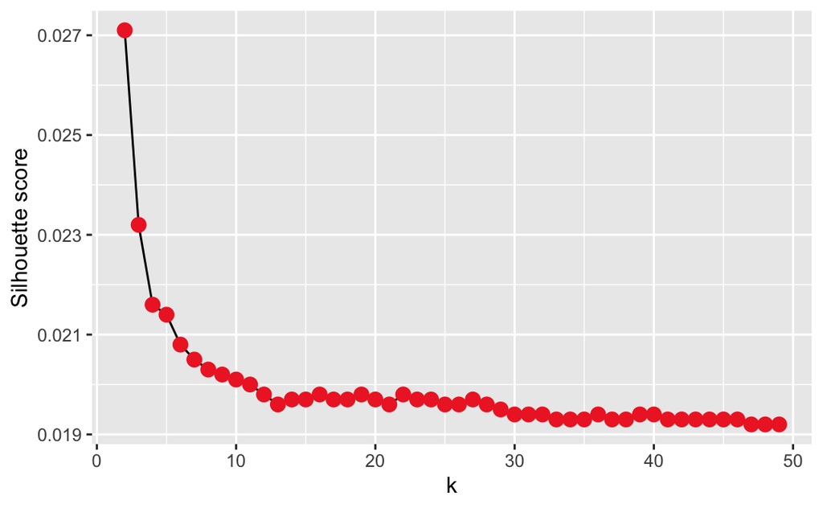

```r
ggplot(silhouette_all,aes(x=k, y=V1)) +
  geom_line() +
  geom_point(size=3, colour="firebrick2") +
  ylab("Silhouette score")
```

## Cluster eigenfeature calculation and clustering visualization

```r
## I manually chose k=20... is this the best choice?
kmedoid_labels <- read.csv(here::here("ibd", "all", "k-med_labels_k20_all.csv"), header=F) %>% as.vector()

clusterinfopep <- kmedoid_labels %>% data.frame()

max_clust <- kmedoid_labels %>% unique() %>% max()
print(paste("Number of clusters:", max_clust))
```

```
[1] "Number of clusters: 19"
```

```r
fc_clusters <- list()

## making sure our FC data is
fc_all <- fc_all %>% dplyr::select(noctrlmeta_all$NewName)
## creating a list that contains intensities of each peptide cluster
for (x in 0:max_clust){
    clustername <- paste("Cluster", x)
    y <- kmedoid_labels[which(kmedoid_labels$V1 == x),,drop=F] %>% rownames()
    fc_clusters[[clustername]] <- fc_all[y %>% as.numeric(),]
    fc_clusters[[clustername]]$feat_num <- y
}

### eigenfactors
### Singular value decomposition for genome-wide expression data processing and modeling
###  https://doi.org/10.1073/pnas.97.18.10101
## https://www.biostars.org/p/299167/
## eigengenes <- svd(X)$v
## We are using PCA
pca_clusters <- lapply(fc_clusters, function(x) prcomp(x %>% dplyr::select(-feat_num) %>% t(), center=T, scale=F)$x)
svd_clusters <- lapply(fc_clusters, function(x) svd(x %>% dplyr::select(-feat_num))$v)
# grabbing the first principal component
svd1_cluster <- lapply(svd_clusters,  "[", , 1)
pc1_cluster <- lapply(pca_clusters,  "[", , 1)
clustereigenfactors_pca <- bind_cols(pc1_cluster) %>% data.frame()
clustereigenfactors_svd <- bind_cols(svd1_cluster) %>% data.frame()
```

Complete the correlation with groups and inflammation.

```r
## make a factored dataframe of the compounds
noctrlmeta_all <- ibd_meta %>% filter(DIagnosis != "Control")
```

[output not shown]

Now, let’s look at *SVD-derived* eigenfeatures (this is the more common way of calculating an eigenfeature).

[output not shown]

[figure not shown]

```r
par(xpd = TRUE) # allows legend to be outside "official" plotting lines
coords2 <- list(x=0, y=0.95)
heatmap.2(moduleTraitCor_svd,
          notecol="black",      # change font color of cell labels to black
          density.info="none",  # turns off density plot inside color legend
          trace="none",         # turns off trace lines inside the heat map
          margins =c(5,0),      # widens margins around plot
          col=new_palette,      #
          breaks=seq(-0.8,0.8,0.01),    # enable color transition at specified limits
          dendrogram="col",     # only draw a row dendrogram
          Colv=drug_dend,            # turn off column clustering
          Rowv=as.dendrogram(module_clust_svd),
          #ColSideColors = cor_meta$drug_col,
          ColSideColors = cor_meta_svd$drug_col,
          labRow = "",
          key.xlab ="Pearson Correlation Coefficient",
          key.title = NA,
          lhei = c(1,4),
          lwid= c(1,3),
          cexCol = 1.2,
          keysize = 1)
```

Check out the average intensity levels of clusters with high correlation with CD, UC. First let’s focus on CD.A

```r
cor_info <- data.frame(moduleTraitCor_svd)
cor_info[27,]

max_CD.A <- which(clusterinfopep$V1 == which.max(cor_info$CD.A)-1)
max_UC.A <- which(clusterinfopep$V1 == which.max(cor_info$UC.A)-1)
max_UC.N <- which(clusterinfopep$V1 == which.max(cor_info$UC.N)-1)
## set up meta to include inflame with control!
ibd_meta <- ibd_meta %>% mutate(group_inflam = paste0(Groups, "_", inflame),
                                Name = paste0(., "_", Groups))

## Make function for this
biomarker_plot <- function(x_group, max_df){
    clust <- log_exp[max_df %>% as.numeric(),]
    clust$feat_num <- max_df
    clust_melt <- clust %>% pivot_longer(!feat_num, names_to="Sample", values_to="log2_intensity")
    clust_melt <- merge(clust_melt, ibd_meta %>% select(Name, group_inflam), by.x="Sample", by.y="Name")
    clust_melt$group_inflam <- factor(clust_melt$group_inflam,
                                           levels = c("Control_N", "CD_A", "UC_A", "UC_N"))
    meanvals <- clust_melt %>% group_by(feat_num, group_inflam) %>%
      dplyr::summarize(averageval = mean(log2_intensity, na.rm=TRUE))
    group_spec <- meanvals %>% filter(group_inflam == x_group)
    group_spec <- group_spec[which.max(group_spec$averageval),] #7882
    group_outlier <- meanvals %>% filter(feat_num == group_spec$feat_num)

     group_plot<- ggplot(meanvals, aes(x=group_inflam, y=averageval, fill=group_inflam)) +
    geom_boxplot(alpha=0.7) +
    scale_fill_manual(name = "Groups", values=c("grey", "#1446A0", "#DB3069", "#FFBA08")) +
    geom_line(data = group_outlier, aes(x=group_inflam, y=averageval, group=1),
              colour = "#59C9A5") +
    geom_point(data = group_outlier, aes(x=group_inflam, y=averageval),shape = 21, fill="#59C9A5", colour = "white", size = 4) +
    ylab("Mean log2 intensity value") +
    xlab("Group")

     return(group_plot)
}

CD.A_plot <-biomarker_plot(x_group = "CD_A", max_df = max_CD.A)
CD.A_plot
#ggsave(here::here("ibd","figs", "CD_A-clust.png"), CD.A_plot, width=7,
#       height=5, units="in")
```

```r
## CD.A
UC.A_plot <-biomarker_plot(x_group = "UC_A", max_df = max_UC.A)
UC.A_plot
#ggsave(here::here("ibd","figs", "UC_A-clust.png"), UC.A_plot, width=7,
#       height=5, units="in")
```

```r
max_df = max_UC.N
x_group = "UC_N"
maxfc_biomarker_plot <- function(x_group, max_df){
    clust <- log_exp[max_df %>% as.numeric(),]
    clust$feat_num <- max_df
    clust_melt <- clust %>% pivot_longer(!feat_num, names_to="Sample", values_to="log2_intensity")
    clust_melt <- merge(clust_melt, ibd_meta %>% select(Name, group_inflam), by.x="Sample", by.y="Name")
    clust_melt$group_inflam <- factor(clust_melt$group_inflam,
                                           levels = c("Control_N", "CD_A", "UC_A", "UC_N"))
    meanvals <- clust_melt %>% group_by(feat_num, group_inflam) %>%
      dplyr::summarize(averageval = mean(log2_intensity, na.rm=TRUE))
    #group_spec <- meanvals %>% filter(group_inflam == x_group)
    #group_spec <- group_spec[which.max(group_spec$averageval),] #7882

    clust_fc <- fc[max_df %>% as.numeric(),]
    clust_fc$feat_num <- max_df
    clust_fc_melt <- clust_fc %>% pivot_longer(!feat_num, names_to="Sample", values_to="log2_fc")
    clust_fc_melt <- merge(clust_fc_melt, ibd_meta %>% select(Name, group_inflam), by.x="Sample", by.y="Name")
    clust_fc_melt$group_inflam <- factor(clust_fc_melt$group_inflam,
                                           levels = c("Control_N", "CD_A", "UC_A", "UC_N"))
    meanvals_fc <- clust_fc_melt %>% group_by(feat_num, group_inflam) %>%
      dplyr::summarize(averageval = mean(log2_fc, na.rm=TRUE))
    group_spec_fc <- meanvals_fc %>% filter(group_inflam == x_group)
    group_spec_fc <- group_spec_fc[which.min(group_spec_fc$averageval),] #7882

    group_fc_outlier <- meanvals %>% filter(feat_num == group_spec_fc$feat_num)

     group_plot<- ggplot(meanvals, aes(x=group_inflam, y=averageval, fill=group_inflam)) +
    geom_boxplot(alpha=0.7) +
    scale_fill_manual(name = "Groups", values=c("grey", "#1446A0", "#DB3069", "#FFBA08")) +
   geom_line(data = group_fc_outlier, aes(x=group_inflam, y=averageval, group=1),
              colour = "#59C9A5") +
    geom_point(data = group_fc_outlier, aes(x=group_inflam, y=averageval),shape = 21, fill="#59C9A5", colour = "white", size = 4) +
    ylab("Mean log2 intensity value") +
    xlab("Group")

     return(group_plot)
}


UC.N_plot <-biomarker_plot(x_group = "UC_N", max_df = max_UC.N)
UC.N_plot
#ggsave(here::here("ibd","figs", "UC_N-clust.png"), UC.N_plot, width=7,
#       height=5, units="in")

UC.N_plot_FC <- maxfc_biomarker_plot(x_group = "UC_N", max_df = max_UC.N)
UC.N_plot_FC
```

# Biomarker discovery through machine learning

The above demonstrates the **potential** to identify biomarkers using this approach. Let’s use a more iterative approach by using machine learning. It is likely that we will need to use a combination of many biomarkers (a panel).

It’s important to consider we have way more predictors than samples (p >> n). We will need a solution that considers this. Check out these manuscript that may help:

- [-Omics biomarker identification pipeline for translational medicine](https://doi.org/10.1186/s12967-019-1912-5)
- [Statistical predictions with glmnet](https://doi.org/10.1186/s13148-019-0730-1)

“Least Absolute Shrinkage and Selection Operator and Elastic Net feature selection methods are applied to identify the most important features representing potential biomarker candidates”… I think we need to use these as

**Penalized regression** Elastic net (`glmnet`) and lasso can be used for feature selection… let’s try them out!

```r
# https://www.r-bloggers.com/2017/09/variable-selection-with-elastic-net/
#x is the data
#y is the response!
# LASSO WITH ALPHA = 1

CD.A_log <- log_exp[max_CD.A,]
## row num is the row we must grab of the filtered data
CD.A_log$row_num <- max_CD.A
## feat number is the actual feature number of the experiment
CD.A_log$feat_num <- rownames(CD.A_log)

ibd_meta_imp <- ibd_meta %>% dplyr::select(Name, group_inflam) %>%
  mutate(CD.A = case_when(group_inflam == "CD_A" ~ 1,
                          group_inflam != "CD_A" ~ 0))
clust27t <- CD.A_log %>% dplyr::select(-ends_with("num")) %>% t() %>% as.data.frame() %>%
  rownames_to_column("Name") %>%
  left_join(ibd_meta_imp, . , by="Name") %>% dplyr::select(-Name, -group_inflam)

clust27_outcome <- clust27t %>% dplyr::select(CD.A) %>% as.matrix(.)
clust27t <- clust27t %>% dplyr::select(-CD.A) %>% as.matrix(.)



## change parallel =T when you can...
set.seed(5550)
## this is just a test since we don't have enough samples!
## Change to different nfold
## LASSO
clust27lasso <- cv.glmnet(clust27t, clust27_outcome, family = "binomial", nfold = 4, type.measure = "deviance", paralle = F, alpha = 1)
model1 <- glmnet(clust27t, clust27_outcome, family = "binomial", lambda = clust27lasso$lambda.1se, alpha = 1)
coef(model1, "lambda.min")

## RIDGE
clust27ridge <- cv.glmnet(clust27t, clust27_outcome, family = "binomial", nfold = 4, type.measure = "deviance", paralle = F, alpha = 0)
model2 <- glmnet(clust27t, clust27_outcome, family = "binomial", lambda = clust27ridge$lambda.1se, alpha = 1)
coef(model2, "lambda.min")

## Elastic Net
a <- seq(0.1, 0.9, 0.05)
search <- foreach(i = a, .combine = rbind) %do% { #replace %do% with %dopar%
  cv <- cv.glmnet(clust27t, clust27_outcome, family = "binomial", nfold = 3, type.measure = "deviance", paralle = F, alpha = a)
  data.frame(cvm = cv$cvm[cv$lambda == cv$lambda.1se], lambda.1se = cv$lambda.1se, alpha = i)
}
cv3 <- search[search$cvm == min(search$cvm), ]
md3 <- glmnet(mdlX, mdlY, family = "binomial", lambda = cv3$lambda.1se, alpha = cv3$alpha)
coef(md3)
```